# Introduction to R

## Packages

- Many contributors have written/ are writing packages that include functionalities.
- The basic $\texttt{R}$ does not come with ALL packages.
- To use them, we will need to install them (only once) and then load (everytime you use it).

## Example 1: $\texttt{R}$ package

- Let’s try installing the $\texttt{car}$ package.

```r
# install.packages("car")    # Installs the package.
# Remove the first "#" from above to run the line
library("car")   #loads the package.
```

## Example 2: What does the cow say?

- Let’s (install and) load the $\texttt{cowsay}$ package.

```r
# install.packages("cowsay")    # Install it once
library("cowsay")
say("Welcome to STA4173 - Biostatistics", by = "cow")
```

```
##
##  -----
## Welcome to STA4173 - Biostatistics
##  ------
##     \   ^__^
##      \  (oo)\ ________
##         (__)\         )\ /\
##              ||------w|
##              ||      ||
```

## Your task

Can you install and load the $\texttt{tidyverse}$ package?

## Data and data.frame

- In $\texttt{R}$, we will analyze and model any data.
- Typically, whenever you load any data, it will be of class $\texttt{data.frame}$.
- Rows of data are different observations, columns are different variables.
- Let’s try the $\texttt{mtcars}$ data that automatically comes with basic $\texttt{R}$.

## Example

```r
data("mtcars") #loads the data for further use
# ?mtcars # Use "?..." to see Help about any package/ function
head(mtcars) # head(...) to see only first 6 rows
```

```
##                    mpg cyl disp  hp drat    wt  qsec vs am gear carb
## Mazda RX4         21.0   6  160 110 3.90 2.620 16.46  0  1    4    4
## Mazda RX4 Wag     21.0   6  160 110 3.90 2.875 17.02  0  1    4    4
## Datsun 710        22.8   4  108  93 3.85 2.320 18.61  1  1    4    1
## Hornet 4 Drive    21.4   6  258 110 3.08 3.215 19.44  1  0    3    1
## Hornet Sportabout 18.7   8  360 175 3.15 3.440 17.02  0  0    3    2
## Valiant           18.1   6  225 105 2.76 3.460 20.22  1  0    3    1
```

## $\texttt{mtcars}$ (Contd.)

#### Q1: How many observations or data points (or how many cars do we have here)?

**Ans:** Count the number of rows.

```r
nrow(mtcars)
```

```
## [1] 32
```

#### Q2: How many variables?

**Ans:** Count the number of columns.

```r
ncol(mtcars)
```

```
## [1] 11
```

## $\texttt{mtcars}$ (Contd.)

#### Q3: What are the variables (or column names)?

```r
colnames(mtcars)
```

```
##  [1] "mpg"  "cyl"  "disp" "hp"   "drat" "wt"   "qsec" "vs"   "am"   "gear"
## [11] "carb"
```

## $\texttt{mtcars}$ (Contd.)

#### Q4: How can I see only the values of the “mpg” variable/colum?

```r
mtcars$mpg
```

```
##  [1] 21.0 21.0 22.8 21.4 18.7 18.1 14.3 24.4 22.8 19.2 17.8 16.4 17.3 15.2 10.4
## [16] 10.4 14.7 32.4 30.4 33.9 21.5 15.5 15.2 13.3 19.2 27.3 26.0 30.4 15.8 19.7
## [31] 15.0 21.4
```

## $\texttt{mtcars}$ (Contd.)

#### Q4a: How can I see only the “disp” variable/column?

```r
#Try it yourself
# Hint: Syntax is <<dataframe name>>$<<column name>>
```

## $\texttt{mtcars}$ (Contd.)

#### Q5: How can I see the maximum and minimum “mpg” of the cars?

```r
max(mtcars$mpg)
```

```
## [1] 33.9
```

```r
min(mtcars$mpg)
```

```
## [1] 10.4
```

## $\texttt{mtcars}$ (Contd.)

#### Q6: How can I plot the “mpg” column against “disp” column?

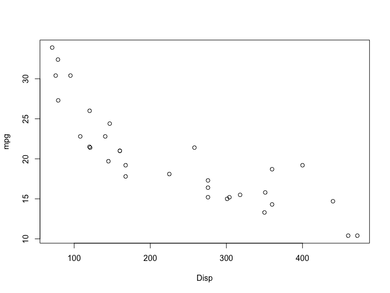

```r
plot(mtcars$disp, mtcars$mpg, xlab = "Disp", ylab = "mpg")
```